# An approach to Sentiment & Network Analysis about cryptocurrencies topics +++on Reddit

### Final Analysis

Una volta pulito il nostro dataset e prese le decisioni riguardo le manipolazioni da effettuare, andiamo ad analizzare la frequenza delle parole, cercando di capire quali siano i temi più influenti trattati nei commenti del subreddit di dogecoin. Per questa parte di analisi verranno rimosse le stopwords dal corpus e andremmo ad utilizzare lo stemming per raggruppare parole con la stessa radice.

In questa sezione verrà proposta un’analisi del corpus del dataset corretto del subreddit di dogecoin, sia rispetto le singole parole presenti, sia utilizzando i bigrammi.

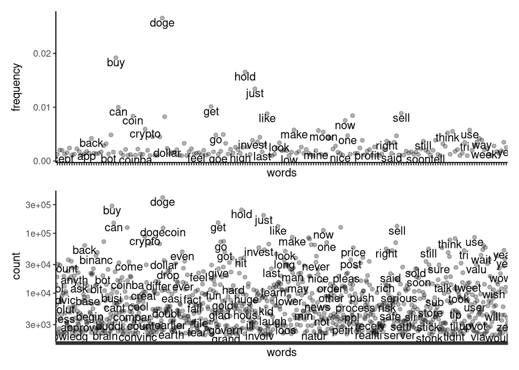

```r
data <- readRDS("../Data/dogecoin.rds")
doge_corpus <- data$corpus_comm
remove(data)

# remove stopwords!!
doge_tidy <- corpus.tokenize_dfmTidy(doge_corpus, spell_checking = TRUE,
    mode_correction = 0)
doge_clean_tidy <- corpus.clean_tidy(doge_tidy$tidy, mode = "stem")
doge_word_counts <- corpus.countPlot_tidy(doge_clean_tidy, threshold_count = 2000)
```

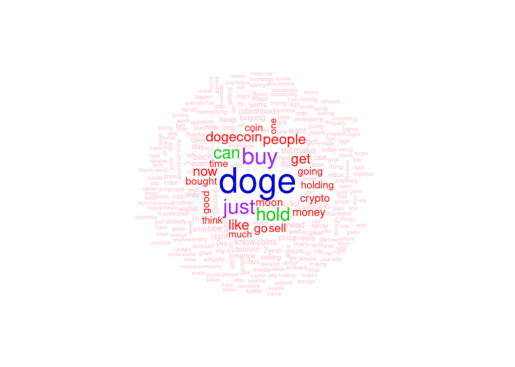

```r
set.seed(190)

dff <- doge_tidy$dfm
# colour of words from least to most frequent
textplot_wordcloud(dff, min_count = 10000, color = c("pink",
    "red", "green3", "purple", "orange", "blue3"))
```

```r
remove(dff)
```

Tra le parole più presenti, oltre a doge, possiamo notare parole come: - buy - hold - moon - invest/keep

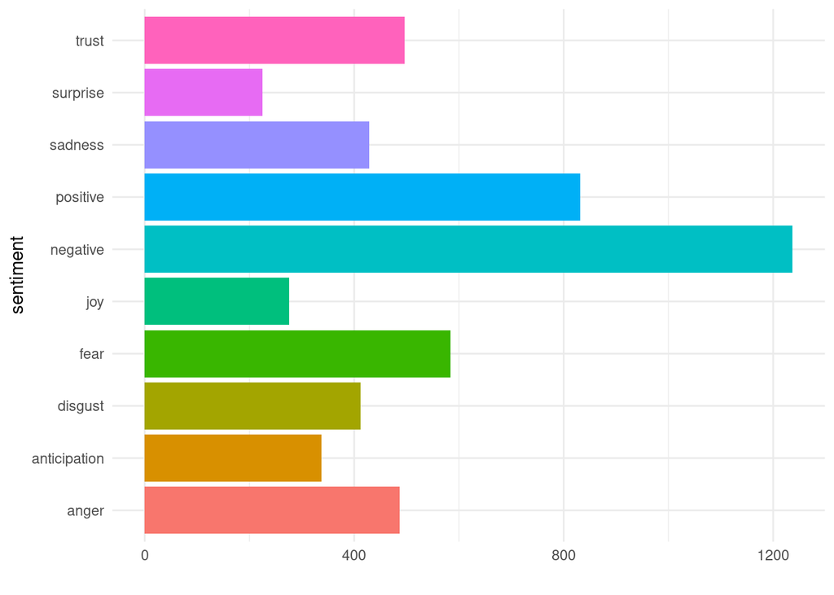

| sentiment | word_4_sentiment |
| --- | --- |
| negative | 1237 |
| positive | 832 |
| fear | 584 |
| trust | 496 |
| anger | 487 |
| sadness | 429 |
| disgust | 412 |
| anticipation | 337 |
| joy | 276 |
| surprise | 225 |

```r
words.classSentiment(doge_word_counts)
```

```r
doge_word_sentiment <- words.computeSentiment(doge_word_counts,
    n_filter = 10)
```

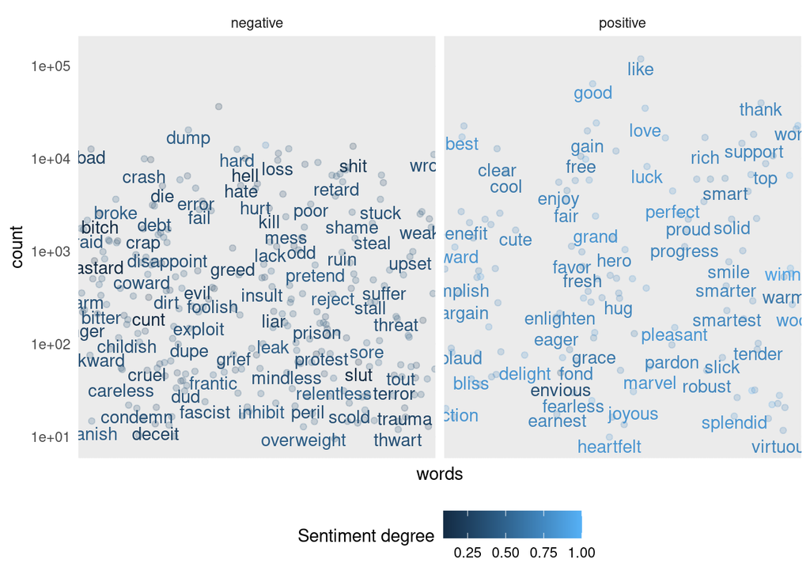

In questo grafico possiamo trovare parole interessanti divise in base alla loro positività. Nella parte negativa si può notare subito come ‘dump,’ termine che in finanza significherebbe far sgonfiare il prezzo, sia molto utilizzata e attorno una serie di parole che non sono legate alla fiducia, ma al contrario fanno capire come il mercato di questa moneta non sia percepito come non stabile. Dall’altra parte ci sono parole che cercano di ingoraggiare all’investimento in dogecoin.

Andiamo però a visualizzare i bigrammi per vedere se queste parole prese con un minimo di contesto facciano presumere le stesse ipotesi.

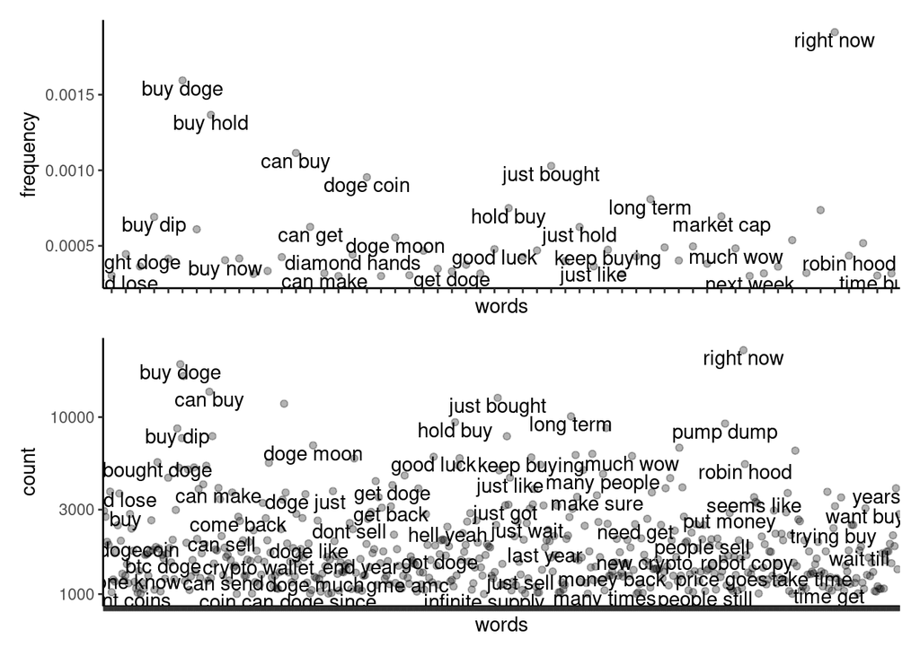

```r
doge_tidy_bigrams <- corpus.tokenize_dfmTidy(doge_corpus, dfm_b = FALSE,
    spell_checking = TRUE, mode_correction = 0, ngrams = 2)

doge_clean_tidy_bigrams <- corpus.clean_tidy(doge_tidy_bigrams$tidy,
    ngrams = 2)
remove(doge_tidy_bigrams)
doge_bigrams_counts <- corpus.countPlot_tidy(doge_clean_tidy_bigrams,
    threshold_freq = 3e-04, ngrams = 2)
```

Analizzando i bigrammi si può notare ancor più maggiormente che la gran parte delle parole si riferiscono a spingere gli utenti ad acquistare e mantenere i dogecoin nel proprio wallet digitale.

```r
bigrams_class_sentiment <- words.classSentiment(doge_bigrams_counts,
    n_filter_sentiment = 10000, ngrams = 2)
```

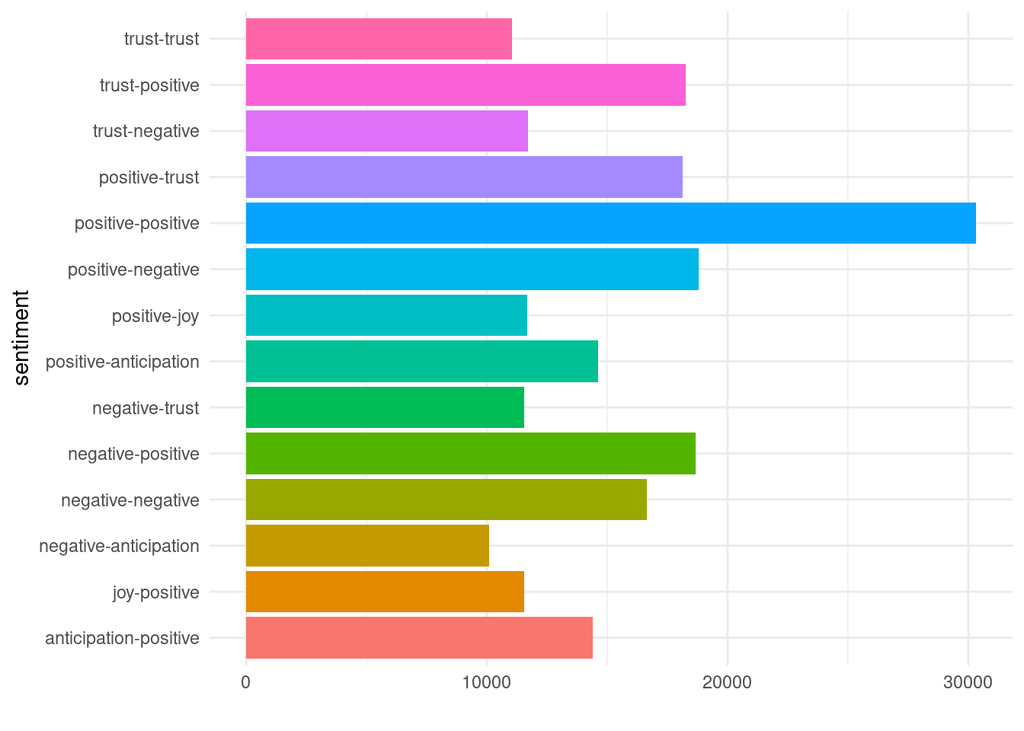

Considerando le classi dei sentimenti sui bigrammi la situazione cambia un poco. Infatti i sentimenti positivi risultano maggiori, ma sempre con un po’ di incertezza considerando i bigrammi in cui viene associato il sentimento di fiducia con sentimenti negativi.

```r
bigrams_sentiment <- words.computeSentiment(doge_bigrams_counts,
    n_filter = 50, ngrams = 2)
```

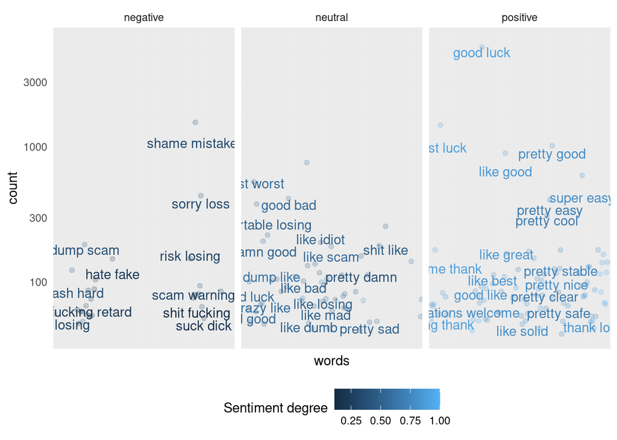

Similmente andando a classificare ciascuna parola in una scala da 0 a 1, che indica la positività di un bigramma, il numero di parole negative sembra essere molto minore a quelle positive.

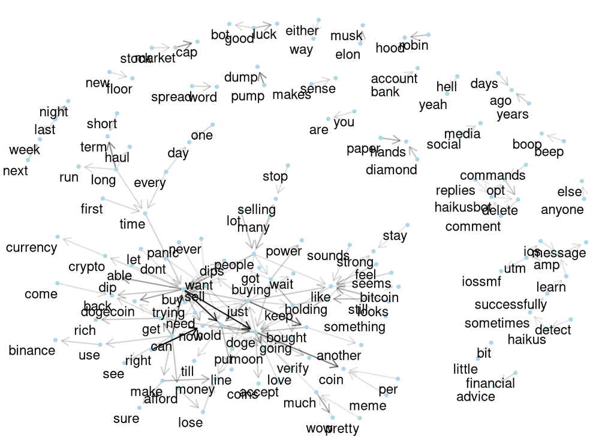

```r
words.network(doge_bigrams_counts, n_filter = 2000)
```

Inoltre, a confermare l’ipotesi che gli utenti spingano all’acquisto e possesso di questa cryptovaluta, c’è l’accostamento della parola “stop” con “selling,” proprio per incentivare a non vendere e quindi a non far calare di prezzo il valore dei dogecoin.

```r
remove(doge_tidy_bigrams)
remove(doge_bigrams_counts)

remove(bigrams_class_sentiment)
remove(bigrams_sentiment)
```

### Comments per Time

```r
data <- readRDS("../Data/dogecoin.rds")
doge_df <- data$df_comm


remove(data)
```

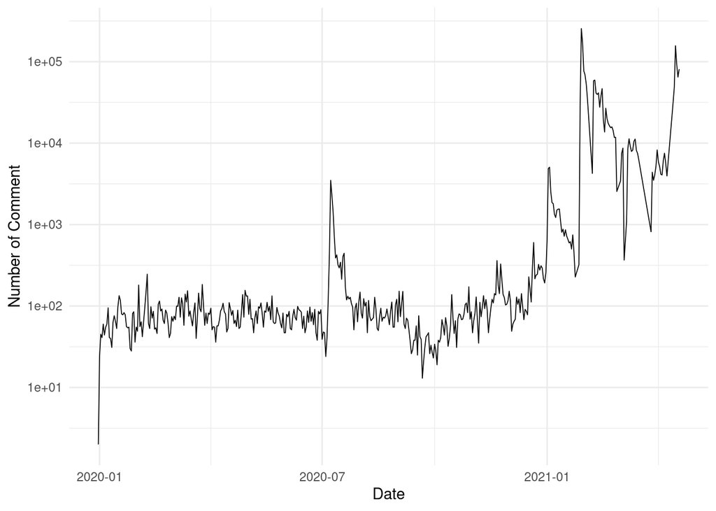

```r
plot_com_per_date <- function(dataset) {

    df_date <- dataset %>%
        select(date, link_id)

    df_date %>%
        group_by(date) %>%
        summarise(n_com = n()) %>%
        arrange(date) %>%
        ggplot(aes(date, n_com)) + geom_line(size = 0.3) + xlab("Date") +
        ylab("Number of Comment") + scale_y_log10() + theme_minimal()
}

# plot for date of comment
plot_com_per_date(doge_df)
```

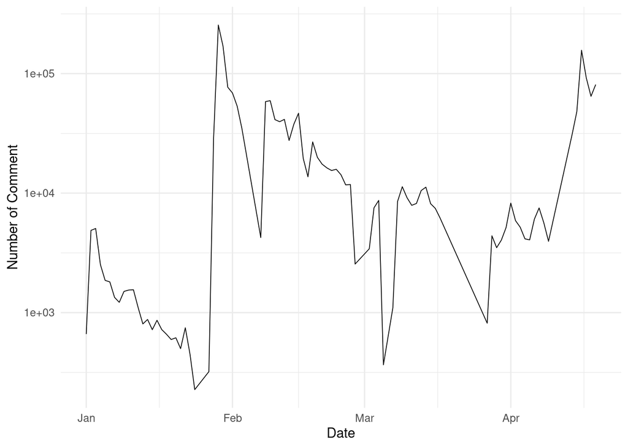

```r
doge_com_2021 <- doge_df %>%
    filter(date > as.Date("2020-12-31"))

plot_com_per_date(doge_com_2021)
```

```r
remove(doge_df)
remove(doge_come_2021)
```

#### Sentiment over Time

Per dare un sentimento ad ogni commento, una volta asseganti i sentimenti a ciascuna parola nei bigrammi del commento, sarà necessario calcolare la polarità generale delle frasi in modo da capirne l’andamento nel tempo.

> Sentiment polarity for an element defines the orientation of the expressed sentiment, i.e., it determines if the text expresses the positive, negative or neutral sentiment of the user about the entity in consideration.

""" Con la funzione *words.computeSentiment* abbiamo definito come assegnare a ciascuna parola il valore rappresentativo per il sentimento. In questa sezione è invece necessario trovare una strategia per rappresentare il sentimento dell’intero commento. """

Si è scelto di utilizzare il concetto di polarità unendolo alla tecnica *Lexicon based* che consiste nel conteggiare il numero di parole positive e negative per assegnare alla frase il sentimento più presente. Si ha quindi per ogni bigramma il suo corrispondete sentimento, che può essere positivo, negativo oppure neutro, successivamente andremo a calcolare il numero di bigrammi per ogni frase in modo da tener conto di questo nel calcolare il valore di sentimento finale per ciascun id corrispondente ad ogni comment.

L’obiettivo di utilizzare il conteggio delle parole nella frase è, avendo molti commenti corti, di dare un maggior peso a frasi in cui possiamo trovare sentimenti contrastanti.

```r
corpus.compute_sentiment_per_comment <- function(tidy_clean_bigrams,
    data_txt) {

    sentiment_per_doc <- tidy_clean_bigrams %>%
        inner_join(get_sentiments("afinn"), by = c(word1 = "word")) %>%
        inner_join(get_sentiments("bing"), by = c(word1 = "word")) %>%
        inner_join(get_sentiments("afinn"), by = c(word2 = "word")) %>%
        inner_join(get_sentiments("bing"), by = c(word2 = "word")) %>%
        mutate(affin = (value.x + value.y)/2) %>%
        mutate(bing = case_when(sentiment.x == "positive" & sentiment.y ==
            "positive" ~ "positive", sentiment.x == "negative" &
            sentiment.y == "negative" ~ "negative", TRUE ~ "neutral")) %>%

    mutate(affin_nrm = range01(affin)) %>%
        unite(words, c("word1", "word2"), sep = " ") %>%
        mutate(id = as.integer(document)) %>%
        select(id, words, affin, affin_nrm, bing)

    sentiment_per_comment <- sentiment_per_doc %>%
        inner_join(data_txt, by = "id") %>%
        select(date, author, id, words, affin, affin_nrm, bing)

    return(sentiment_per_comment)
}
```

Leggiamo il file della cartella Data per ottenere un oggetto tidy contenente i token del corpus ottenuti dalla sua correzione tramite il valore TRUE assegnato all’argomento *spell_checking*.

```
# compute bigrams
doge_tidy_bigrams <- corpus.tokenize_dfmTidy(doge_corpus,
                                          dfm_b = FALSE,
                                          remove_stop = FALSE,
                                          spell_checking = TRUE,
                                          mode_correction = 0,
                                          ngrams=2)

 doge_tidy_bigrams <- corpus.clean_tidy(doge_tidy_bigrams$tidy,
                                                     ngrams = 2)

saveRDS(doge_tidy_bigrams, "../Data/tidy_correction_bi_complete.rds")
remove(doge_tidy_bigrams)
```

```
tidy_clean_spell_tok <- readRDS("../Data/tidy_correction_bi_complete.rds")
```

```r
# sentiment per comment
sent_per_comm_dogeBi <- corpus.compute_sentiment_per_comment(doge_clean_tidy_bigrams,
    doge_df)

remove(doge_clean_tidy_bigrams)
```

Da questa funzione ci viene restituito un tabella contente le variabili descrittive per identificare l’id di ogni comment, i bigrammi per ogni id e l’insieme di valori che identificano il sentimento.

Proviamo quindi a raggruppare e conteggiare i bigrammi per commento.

```r
Bi_per_id <- sent_per_comm_dogeBi %>%
    group_by(id) %>%
    count()

# max(Bi_per_id$n)


sent_per_comm_dogeBi = sent_per_comm_dogeBi %>%
    inner_join(Bi_per_id, by = "id")

remove(Bi_per_id)
```

```r
sigmoid <- function(x) {
    sig = 1/(1 + exp(-{
        {
            x
        }
    }))
    return(sig)
}

fatt <- function(x) {
    ifelse(x == 1, 1, x * fatt(x - 1))
}

polarity <- function(pos, neg, neut) {

}


over_time_sentiment <- sent_per_comm_dogeBi %>%
    count(bing, id) %>%
    # aggregate split with count of sentiment
spread(bing, n, fill = 0) %>%
    # for each comment pos, neg, neut count
mutate(polarity = (positive + neutral * 0.4) - (negative + neutral *
    0.6)) %>%
    # if pol is neg -> neg
mutate(polarity = as.numeric(polarity)) %>%
    # dimension of comment (bigrams count)
rowwise() %>%
    mutate(dim = sum(positive, negative, neutral)) %>%
    # moltiplichiamo la polarità per il fattoriale di
# dimensione+1 e dividiamo per la dimensione In questo modo i
# commenti con maggior numero di bigrammi avrà un peso molto
# maggiore agli altri
mutate(polarity_dim = as.double(polarity) * fatt(dim + 1)/dim) %>%
    # standardizziamo tra [0,1] e [-1, 1]
mutate(polarity_sig_dim = sigmoid(polarity_dim)) %>%
    mutate(polarity_tan_dim = tanh(polarity_dim)) %>%
    mutate(polarity_sig = sigmoid(polarity)) %>%
    mutate(polarity_tan = tanh(polarity))
```

```r
color_plot <- function(x) {
    ifelse(x >= 0.5, "green3", ifelse(x <= -0.5, "orangered2",
        "grey"))
}

plot_year_sentiment <- function(data, in_year, pol) {

    plot <- data %>%
        mutate(year_ = year(date)) %>%
        filter(year_ == in_year) %>%
        mutate(month = month(date)) %>%
        mutate(dayMonth = as.numeric(day(date))) %>%
        mutate(col = color_plot({
            {
                pol
            }
        })) %>%
        ggplot(aes(dayMonth, {
            {
                pol
            }
        }, color = col)) + geom_col() + # geom_smooth(method = 'loess', se = FALSE,
    # aes(color='black')) + geom_smooth(method = 'lm', se =
    # FALSE, aes(color='steelblue1') ) +
    facet_grid(facets = month ~ ., margins = FALSE) + # scale_y_continuous(trans = scales::pseudo_log_trans()) +
    theme_minimal() + theme(plot.title = element_text(size = 11),
        axis.text.x = element_blank(), axis.text.y.left = element_blank(),
        legend.position = "none") + xlab(NULL) + ylab(NULL) +
        ggtitle("Polarity Over Time")

    print(plot)
}
```

Utilizziamo un grafico ad istogramma per visualizzare le distribuzioni di frequenza delle polarity, così da capire come visualizzare l’informazione.

```r
head(over_time_sentiment, 5)
```

| id | negative | neutral | positive | polarity | dim | polarity_dim | polarity_sig_dim | polarity_tan_dim | polarity_sig | polarity_tan |
| --- | --- | --- | --- | --- | --- | --- | --- | --- | --- | --- |
| 2 | 3 | 0 | 0 | -3.0 | 3 | -24.0 | 3.775135e-11 | -1.0000000 | 0.04742587 | -0.9950548 |
| 4 | 0 | 0 | 1 | 1.0 | 1 | 2.0 | 8.807971e-01 | 0.9640276 | 0.73105858 | 0.7615942 |
| 37 | 0 | 0 | 1 | 1.0 | 1 | 2.0 | 8.807971e-01 | 0.9640276 | 0.73105858 | 0.7615942 |
| 49 | 0 | 1 | 0 | -0.2 | 1 | -0.4 | 4.013123e-01 | -0.3799490 | 0.45016600 | -0.1973753 |
| 91 | 0 | 0 | 2 | 2.0 | 2 | 6.0 | 9.975274e-01 | 0.9999877 | 0.88079708 | 0.9640276 |

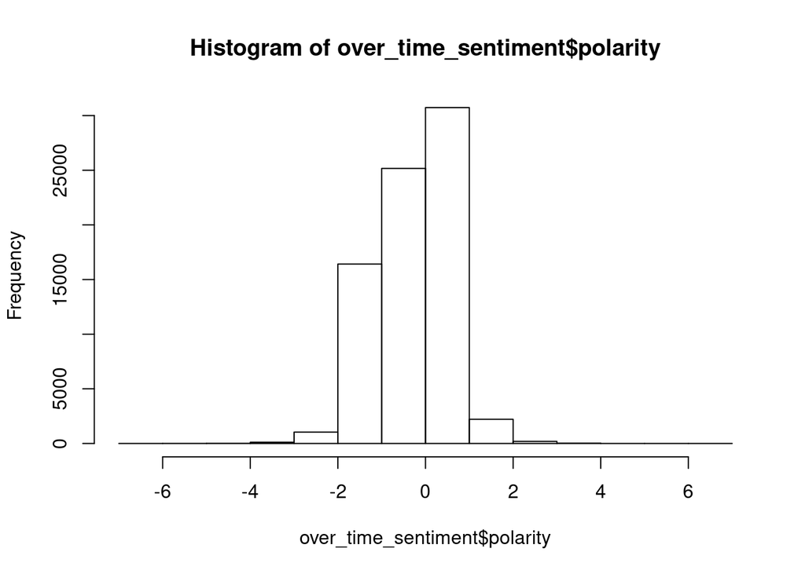

```r
# dist of polarity values
hist(over_time_sentiment$polarity)
```

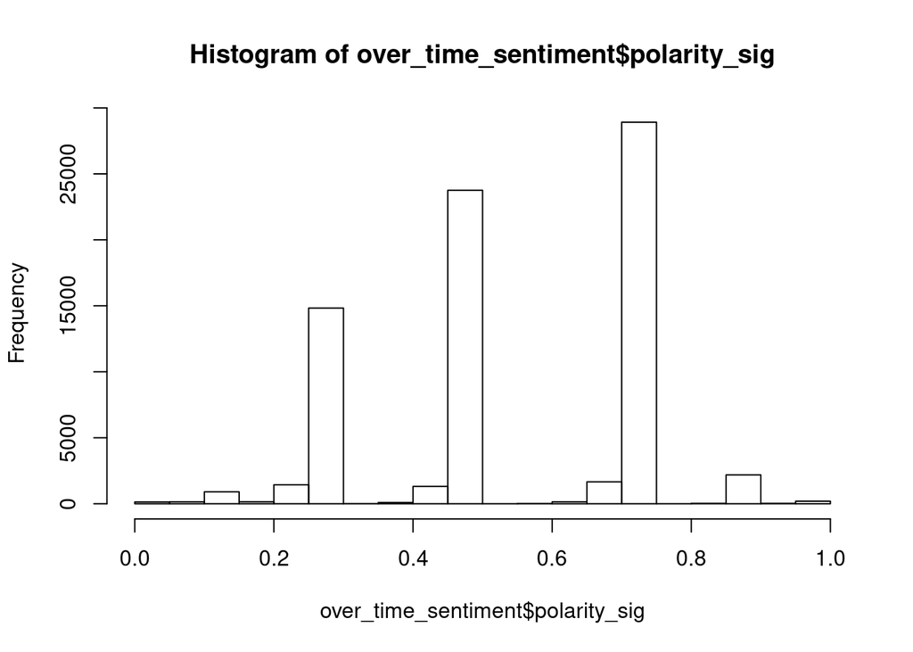

```r
# normalize with tanh
hist(over_time_sentiment$polarity_sig)
```

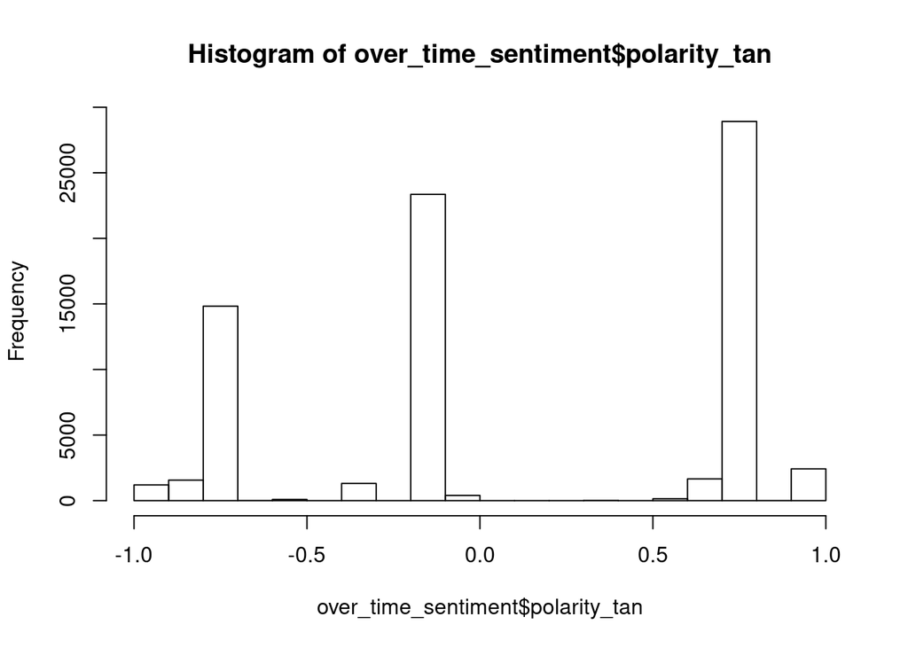

```r
# normalize with sigmoid
hist(over_time_sentiment$polarity_tan)
```

Utilizzando la formula per tenere conto anche della dimensione del commento, abbiamo delle variazione nel valore numerico della polarità, ma le classi positivo-negativo-neutro identificate dagli intervalli, rispettivamente [0.5, 1], [-0.5, 0.5] e [-1, 0.5] rimangono invariate.

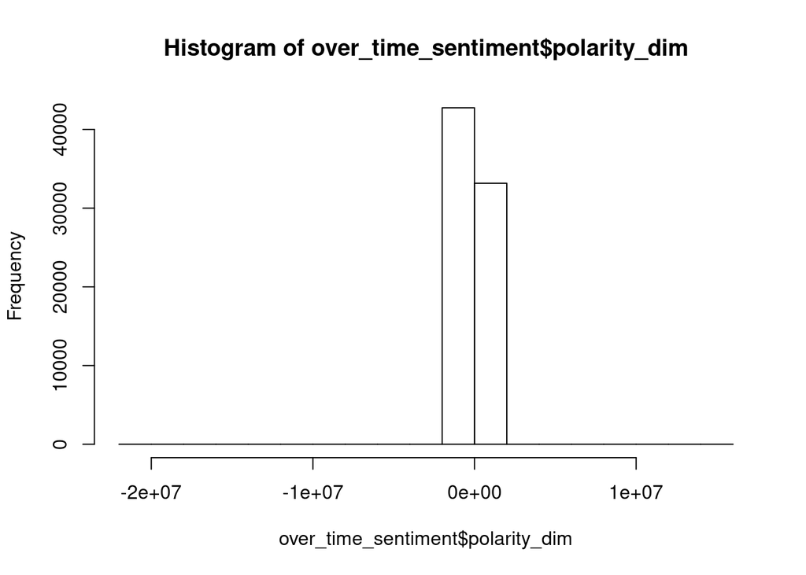

```r
hist(over_time_sentiment$polarity_dim)
```

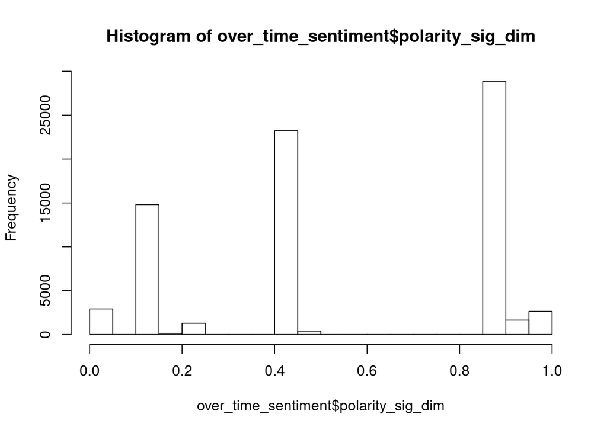

```r
# normalize with tanh
hist(over_time_sentiment$polarity_sig_dim)
```

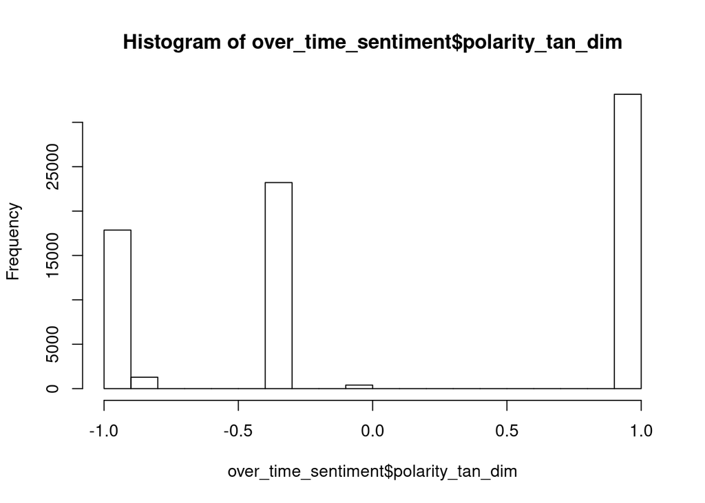

```r
# normalize with sigmoid
hist(over_time_sentiment$polarity_tan_dim)
```

```r
# re-join date

over_time_sentiment_date <- over_time_sentiment %>%
    inner_join(sent_per_comm_dogeBi, by = "id") %>%
    distinct(id, .keep_all = TRUE) %>%
    select(date, id, polarity, polarity_tan, polarity_tan_dim)
```

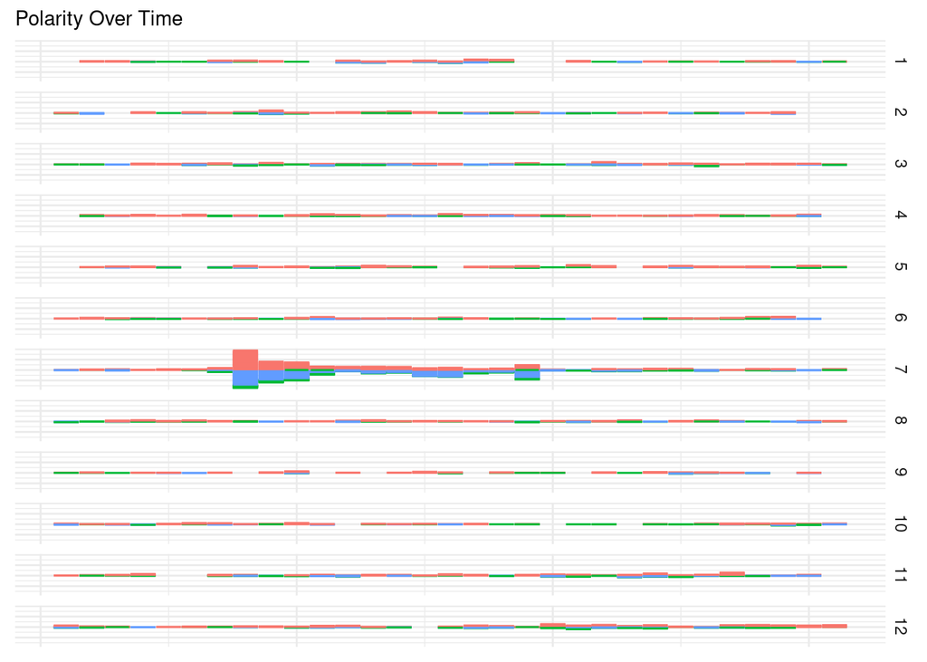

```r
plot_year_sentiment(over_time_sentiment_date, "2020", polarity_tan)
```

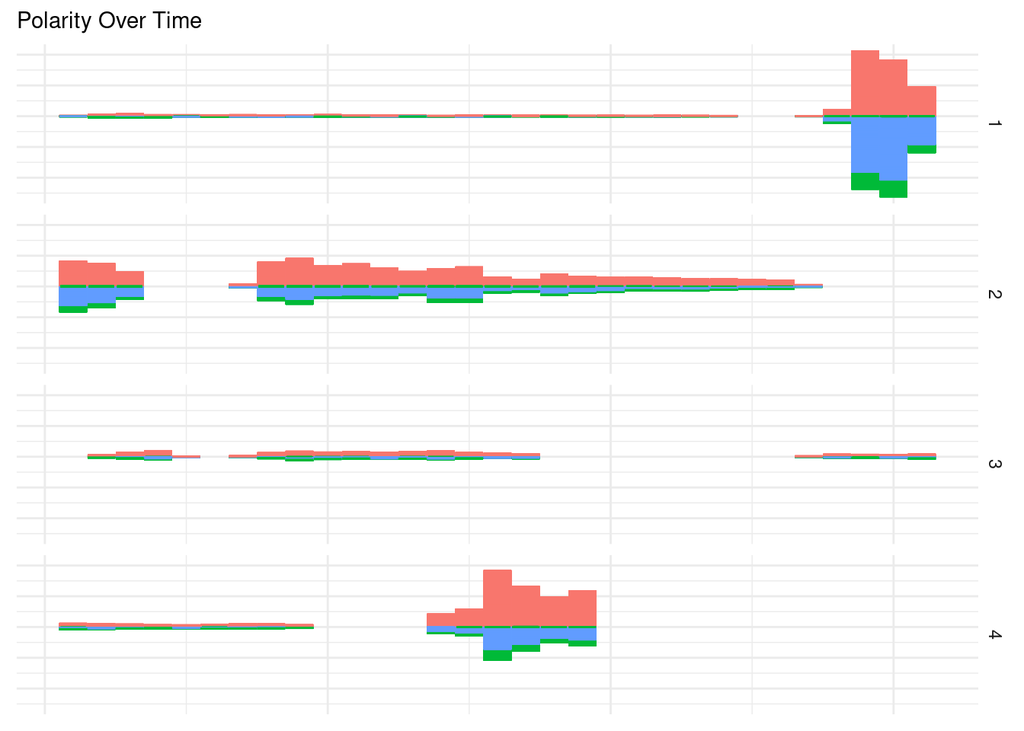

```r
plot_year_sentiment(over_time_sentiment_date, "2021", polarity_tan)
```

#### Average Sentiment Polarity for each day

```
over_time_setiment_date_avg <- over_time_sentiment %>%
      group_by(date) %>%
      mutate(mean_pol = mean(polarity_tan))
```

#### Comparison with an advanced tools for sentiment analysis on social media

Riscontrando molte problematiche dovute ai testi del social media e al limitato vocabolario per la sentiment analysis si è deciso di approfondire le tecniche utilizzate in letteratura. Si è trovato questo articolo del 2020 riguardante un analisi fatta su Twitter riguardo il tema Bitcoin, in cui viene utilizzata una nuova tecnica chiamata VADER.

Si è quindi provato ad utilizzarla su un sottoinsieme del dataset.

VADER-Sentiment-Analysis

VADER ( Valence Aware Dictionary for Sentiment Reasoning) is a model used for text sentiment analysis that is sensitive to both polarity (positive/negative) and intensity (strength) of emotion. It is available in the NLTK package and can be applied directly to unlabeled text data.

VADER sentimental analysis relies on a dictionary that maps lexical features to emotion intensities known as sentiment scores. The sentiment score of a text can be obtained by summing up the intensity of each word in the text.

For example- Words like ‘love,’ ‘enjoy,’ ‘happy,’ ‘like’ all convey a positive sentiment. Also VADER is intelligent enough to understand the basic context of these words, such as “did not love” as a negative statement. It also understands the emphasis of capitalization and punctuation, such as “ENJOY”

```
library(vader)

colnames(doge_df)

df_for_vader <- doge_df %>%
   mutate(year = year(date)) %>%
   mutate(month = month(date)) %>%
   filter(year == "2021",
          month == 2) %>%
   head(10)



df_for_vader %>%
   head(2) %>%
   mutate(scores = list(get_vader(df_for_vader$body))) %>%
   unnest(scores)
```

## Sentiment for User

- join on id, over_time_sentiment with original set with users
- compute polarity (avg of comment polarity)
- retrieve upvote for each comment

Thurner, Stefan, Rudolf Hanel, Bo Liu, and Bernat Corominas-Murtra. 2015. “Understanding Zipf’s Law of Word Frequencies Through Sample-Space Collapse in Sentence Formation.” *Journal of The Royal Society Interface* 12 (108): 20150330. https://doi.org/10.1098/rsif.2015.0330.